# Project: Investigate a Dataset (No Show Appointment)

- Introduction
- Data Wrangling
- Exploratory Data Analysis
- Conclusions

## Introduction

> No show appointment dataset contain the attended appointmrnt for patients. it contain 100K medical appointments in the Brazil. This dataset focus on the number of attended patients or if the patients didn't show up.

> In this project will defined which gender wasn't show up, and in which age who didn't attend mostly.

```python
# set up import statements for all of the packages will be used
import pandas as pd
import numpy as np
import matplotlib.pyplot as plt
%matplotlib inline
```

## Data Wrangling

> No show data set contain patient data such as(Patient ID, Appointment ID, Gender, Schedualed day, Appointment day, Age, Nighhbourhood, Scholarship, Hipertension, Diabetes, Alcoholism, Handcap, SMS_received , and No-show)

### General Properties

```python
# Load data and print out a few lines.
df = pd.read_csv('noshowappointments-kagglev2-may-2016.csv')
df.head()
```

|  | PatientId | AppointmentID | Gender | ScheduledDay | AppointmentDay | Age | Neighbourhood | Scholarship | Hipertension | Diabetes | Alcoholism | Handcap | SMS_received | No-show |
| --- | --- | --- | --- | --- | --- | --- | --- | --- | --- | --- | --- | --- | --- | --- |
| 0 | 2.987250e+13 | 5642903 | F | 2016-04-29T18:38:08Z | 2016-04-29T00:00:00Z | 62 | JARDIM DA PENHA | 0 | 1 | 0 | 0 | 0 | 0 | No |
| 1 | 5.589978e+14 | 5642503 | M | 2016-04-29T16:08:27Z | 2016-04-29T00:00:00Z | 56 | JARDIM DA PENHA | 0 | 0 | 0 | 0 | 0 | 0 | No |
| 2 | 4.262962e+12 | 5642549 | F | 2016-04-29T16:19:04Z | 2016-04-29T00:00:00Z | 62 | MATA DA PRAIA | 0 | 0 | 0 | 0 | 0 | 0 | No |
| 3 | 8.679512e+11 | 5642828 | F | 2016-04-29T17:29:31Z | 2016-04-29T00:00:00Z | 8 | PONTAL DE CAMBURI | 0 | 0 | 0 | 0 | 0 | 0 | No |
| 4 | 8.841186e+12 | 5642494 | F | 2016-04-29T16:07:23Z | 2016-04-29T00:00:00Z | 56 | JARDIM DA PENHA | 0 | 1 | 1 | 0 | 0 | 0 | No |

```python
#Data fram shape
df.shape
```

```
(110527, 14)
```

```python
#Apply describe to show some statistical details
df.describe()
```

|  | PatientId | AppointmentID | Age | Scholarship | Hipertension | Diabetes | Alcoholism | Handcap | SMS_received |
| --- | --- | --- | --- | --- | --- | --- | --- | --- | --- |
| count | 1.105270e+05 | 1.105270e+05 | 110527.000000 | 110527.000000 | 110527.000000 | 110527.000000 | 110527.000000 | 110527.000000 | 110527.000000 |
| mean | 1.474963e+14 | 5.675305e+06 | 37.088874 | 0.098266 | 0.197246 | 0.071865 | 0.030400 | 0.022248 | 0.321026 |
| std | 2.560949e+14 | 7.129575e+04 | 23.110205 | 0.297675 | 0.397921 | 0.258265 | 0.171686 | 0.161543 | 0.466873 |
| min | 3.921784e+04 | 5.030230e+06 | -1.000000 | 0.000000 | 0.000000 | 0.000000 | 0.000000 | 0.000000 | 0.000000 |
| 25% | 4.172614e+12 | 5.640286e+06 | 18.000000 | 0.000000 | 0.000000 | 0.000000 | 0.000000 | 0.000000 | 0.000000 |
| 50% | 3.173184e+13 | 5.680573e+06 | 37.000000 | 0.000000 | 0.000000 | 0.000000 | 0.000000 | 0.000000 | 0.000000 |
| 75% | 9.439172e+13 | 5.725524e+06 | 55.000000 | 0.000000 | 0.000000 | 0.000000 | 0.000000 | 0.000000 | 1.000000 |
| max | 9.999816e+14 | 5.790484e+06 | 115.000000 | 1.000000 | 1.000000 | 1.000000 | 1.000000 | 4.000000 | 1.000000 |

```python
# look for instances of missing or possibly errant data.
df.info()
```

```
<class 'pandas.core.frame.DataFrame'>
RangeIndex: 110527 entries, 0 to 110526
Data columns (total 14 columns):
PatientId         110527 non-null float64
AppointmentID     110527 non-null int64
Gender            110527 non-null object
ScheduledDay      110527 non-null object
AppointmentDay    110527 non-null object
Age               110527 non-null int64
Neighbourhood     110527 non-null object
Scholarship       110527 non-null int64
Hipertension      110527 non-null int64
Diabetes          110527 non-null int64
Alcoholism        110527 non-null int64
Handcap           110527 non-null int64
SMS_received      110527 non-null int64
No-show           110527 non-null object
dtypes: float64(1), int64(8), object(5)
memory usage: 11.8+ MB
```

> There is NO missing data

```python
#Apply the number of duplicated
sum(df.duplicated())
```

```
0
```

> There is no duplicated value, we can say No show data set isn't contain missing data or duplicated data which is a clean data.

> but there are invalied value like -1 and 0 in age as show below

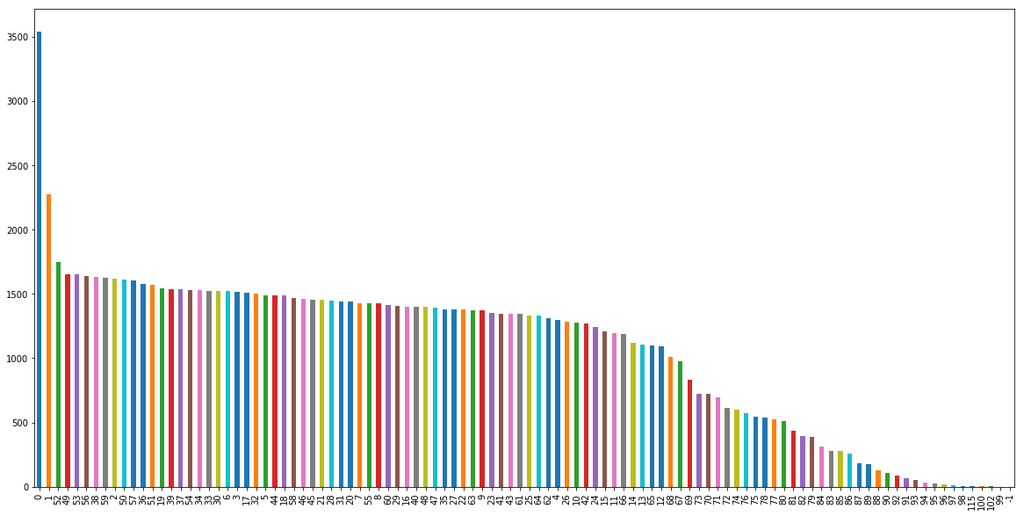

```python
#visulize the age by using bar chart
df['Age'].value_counts().plot(kind='bar', figsize=(20,10));
```

> For that we will filter the data set to the valied age

```python
#Generate condition for the valied age
a = df['Age'] > 0
#Genarate variable
df_a = df[a]
#show the shape for the new data fram
df_a.shape
```

```
(106987, 14)
```

> Also we have the appointment day comes before the scheduled day

```python
#Genarate condition the valied appointment day
ap=df_a['AppointmentDay'] > df_a['ScheduledDay']
#Genarate variable
df_all=df_a[ap]
#show the shape for the new data fram
df_all.shape
```

```
(69828, 14)
```

```python
#show the new data fram
df_all
```

|  | PatientId | AppointmentID | Gender | ScheduledDay | AppointmentDay | Age | Neighbourhood | Scholarship | Hipertension | Diabetes | Alcoholism | Handcap | SMS_received | No-show |
| --- | --- | --- | --- | --- | --- | --- | --- | --- | --- | --- | --- | --- | --- | --- |
| 5 | 9.598513e+13 | 5626772 | F | 2016-04-27T08:36:51Z | 2016-04-29T00:00:00Z | 76 | REPÚBLICA | 0 | 1 | 0 | 0 | 0 | 0 | No |
| 6 | 7.336882e+14 | 5630279 | F | 2016-04-27T15:05:12Z | 2016-04-29T00:00:00Z | 23 | GOIABEIRAS | 0 | 0 | 0 | 0 | 0 | 0 | Yes |
| 7 | 3.449833e+12 | 5630575 | F | 2016-04-27T15:39:58Z | 2016-04-29T00:00:00Z | 39 | GOIABEIRAS | 0 | 0 | 0 | 0 | 0 | 0 | Yes |
| 9 | 7.812456e+13 | 5629123 | F | 2016-04-27T12:48:25Z | 2016-04-29T00:00:00Z | 19 | CONQUISTA | 0 | 0 | 0 | 0 | 0 | 0 | No |
| 10 | 7.345362e+14 | 5630213 | F | 2016-04-27T14:58:11Z | 2016-04-29T00:00:00Z | 30 | NOVA PALESTINA | 0 | 0 | 0 | 0 | 0 | 0 | No |
| 11 | 7.542951e+12 | 5620163 | M | 2016-04-26T08:44:12Z | 2016-04-29T00:00:00Z | 29 | NOVA PALESTINA | 0 | 0 | 0 | 0 | 0 | 1 | Yes |
| 12 | 5.666548e+14 | 5634718 | F | 2016-04-28T11:33:51Z | 2016-04-29T00:00:00Z | 22 | NOVA PALESTINA | 1 | 0 | 0 | 0 | 0 | 0 | No |
| 13 | 9.113946e+14 | 5636249 | M | 2016-04-28T14:52:07Z | 2016-04-29T00:00:00Z | 28 | NOVA PALESTINA | 0 | 0 | 0 | 0 | 0 | 0 | No |
| 14 | 9.988472e+13 | 5633951 | F | 2016-04-28T10:06:24Z | 2016-04-29T00:00:00Z | 54 | NOVA PALESTINA | 0 | 0 | 0 | 0 | 0 | 0 | No |
| 15 | 9.994839e+10 | 5620206 | F | 2016-04-26T08:47:27Z | 2016-04-29T00:00:00Z | 15 | NOVA PALESTINA | 0 | 0 | 0 | 0 | 0 | 1 | No |
| 16 | 8.457439e+13 | 5633121 | M | 2016-04-28T08:51:47Z | 2016-04-29T00:00:00Z | 50 | NOVA PALESTINA | 0 | 0 | 0 | 0 | 0 | 0 | No |
| 17 | 1.479497e+13 | 5633460 | F | 2016-04-28T09:28:57Z | 2016-04-29T00:00:00Z | 40 | CONQUISTA | 1 | 0 | 0 | 0 | 0 | 0 | Yes |
| 18 | 1.713538e+13 | 5621836 | F | 2016-04-26T10:54:18Z | 2016-04-29T00:00:00Z | 30 | NOVA PALESTINA | 1 | 0 | 0 | 0 | 0 | 1 | No |
| 20 | 6.222575e+14 | 5626083 | F | 2016-04-27T07:51:14Z | 2016-04-29T00:00:00Z | 30 | NOVA PALESTINA | 0 | 0 | 0 | 0 | 0 | 0 | Yes |
| 21 | 1.215484e+13 | 5628338 | F | 2016-04-27T10:50:45Z | 2016-04-29T00:00:00Z | 4 | CONQUISTA | 0 | 0 | 0 | 0 | 0 | 0 | Yes |
| 22 | 8.632298e+14 | 5616091 | M | 2016-04-25T13:29:16Z | 2016-04-29T00:00:00Z | 13 | CONQUISTA | 0 | 0 | 0 | 0 | 0 | 1 | Yes |
| 23 | 2.137540e+14 | 5634142 | F | 2016-04-28T10:27:05Z | 2016-04-29T00:00:00Z | 46 | CONQUISTA | 0 | 0 | 0 | 0 | 0 | 0 | No |
| 25 | 5.819370e+12 | 5624020 | M | 2016-04-26T15:04:17Z | 2016-04-29T00:00:00Z | 46 | CONQUISTA | 0 | 1 | 0 | 0 | 0 | 1 | No |
| 27 | 1.215484e+13 | 5628345 | F | 2016-04-27T10:51:45Z | 2016-04-29T00:00:00Z | 4 | CONQUISTA | 0 | 0 | 0 | 0 | 0 | 0 | No |
| 30 | 3.428156e+11 | 5628068 | F | 2016-04-27T10:24:52Z | 2016-04-29T00:00:00Z | 46 | NOVA PALESTINA | 0 | 0 | 0 | 0 | 0 | 0 | No |
| 31 | 3.112849e+11 | 5628907 | M | 2016-04-27T12:07:14Z | 2016-04-29T00:00:00Z | 12 | NOVA PALESTINA | 1 | 0 | 0 | 0 | 0 | 0 | Yes |
| 33 | 7.653517e+12 | 5616921 | F | 2016-04-25T15:01:04Z | 2016-04-29T00:00:00Z | 38 | SÃO CRISTÓVÃO | 1 | 0 | 0 | 0 | 0 | 1 | No |
| 38 | 5.873316e+12 | 5609446 | M | 2016-04-20T15:54:18Z | 2016-04-29T00:00:00Z | 85 | SÃO CRISTÓVÃO | 0 | 1 | 0 | 0 | 0 | 1 | No |
| 40 | 9.968684e+14 | 5635881 | F | 2016-04-28T14:14:16Z | 2016-04-29T00:00:00Z | 55 | TABUAZEIRO | 0 | 0 | 0 | 0 | 0 | 0 | No |
| 41 | 8.224325e+14 | 5633339 | F | 2016-04-28T09:20:36Z | 2016-04-29T00:00:00Z | 71 | MARUÍPE | 0 | 0 | 1 | 0 | 0 | 0 | No |
| 42 | 2.596543e+13 | 5632906 | F | 2016-04-28T08:34:54Z | 2016-04-29T00:00:00Z | 50 | SÃO CRISTÓVÃO | 0 | 0 | 0 | 0 | 0 | 0 | No |
| 44 | 2.741649e+11 | 5635414 | F | 2016-04-28T13:27:27Z | 2016-04-29T00:00:00Z | 78 | SÃO CRISTÓVÃO | 0 | 1 | 1 | 0 | 0 | 0 | Yes |
| 45 | 4.982379e+12 | 5635842 | F | 2016-04-28T14:11:24Z | 2016-04-29T00:00:00Z | 31 | SÃO CRISTÓVÃO | 0 | 0 | 0 | 0 | 0 | 0 | No |
| 46 | 1.379437e+11 | 5615608 | M | 2016-04-25T12:44:36Z | 2016-04-29T00:00:00Z | 58 | SÃO CRISTÓVÃO | 0 | 1 | 0 | 1 | 0 | 1 | No |
| 47 | 5.894585e+11 | 5633116 | F | 2016-04-28T08:51:26Z | 2016-04-29T00:00:00Z | 39 | MARUÍPE | 0 | 1 | 1 | 0 | 0 | 0 | No |
| ... | ... | ... | ... | ... | ... | ... | ... | ... | ... | ... | ... | ... | ... | ... |
| 110451 | 3.681872e+13 | 5760367 | F | 2016-06-01T14:45:45Z | 2016-06-06T00:00:00Z | 34 | RESISTÊNCIA | 0 | 0 | 0 | 0 | 0 | 1 | No |
| 110452 | 6.338837e+14 | 5701786 | F | 2016-05-16T11:00:12Z | 2016-06-06T00:00:00Z | 39 | RESISTÊNCIA | 0 | 1 | 0 | 0 | 0 | 1 | No |
| 110461 | 3.346245e+12 | 5628114 | F | 2016-04-27T10:29:36Z | 2016-06-03T00:00:00Z | 13 | RESISTÊNCIA | 0 | 0 | 0 | 0 | 0 | 1 | Yes |
| 110463 | 8.567868e+12 | 5627377 | F | 2016-04-27T09:24:46Z | 2016-06-03T00:00:00Z | 20 | RESISTÊNCIA | 0 | 0 | 0 | 0 | 0 | 1 | No |
| 110466 | 8.222960e+11 | 5772302 | F | 2016-06-03T15:06:15Z | 2016-06-07T00:00:00Z | 19 | RESISTÊNCIA | 0 | 0 | 0 | 0 | 0 | 1 | No |
| 110468 | 3.227475e+11 | 5763322 | F | 2016-06-02T08:49:21Z | 2016-06-07T00:00:00Z | 76 | RESISTÊNCIA | 0 | 1 | 1 | 0 | 0 | 1 | No |
| 110469 | 8.322564e+14 | 5656075 | F | 2016-05-04T07:35:31Z | 2016-06-07T00:00:00Z | 51 | RESISTÊNCIA | 0 | 0 | 0 | 0 | 0 | 1 | Yes |
| 110470 | 4.125933e+12 | 5692391 | F | 2016-05-12T15:12:01Z | 2016-06-02T00:00:00Z | 26 | RESISTÊNCIA | 0 | 0 | 0 | 0 | 0 | 1 | Yes |
| 110476 | 9.278752e+12 | 5678369 | F | 2016-05-10T08:25:25Z | 2016-06-06T00:00:00Z | 80 | RESISTÊNCIA | 0 | 1 | 0 | 0 | 0 | 1 | No |
| 110477 | 2.798494e+13 | 5673472 | F | 2016-05-09T09:24:09Z | 2016-06-06T00:00:00Z | 67 | RESISTÊNCIA | 0 | 0 | 1 | 0 | 0 | 1 | No |
| 110478 | 5.478497e+12 | 5671780 | F | 2016-05-09T07:11:08Z | 2016-06-06T00:00:00Z | 27 | RESISTÊNCIA | 0 | 0 | 0 | 0 | 0 | 1 | No |
| 110479 | 4.455244e+12 | 5638153 | F | 2016-04-29T07:45:43Z | 2016-06-06T00:00:00Z | 34 | RESISTÊNCIA | 1 | 0 | 0 | 0 | 0 | 1 | Yes |
| 110480 | 3.492935e+11 | 5606687 | F | 2016-04-20T10:33:54Z | 2016-06-06T00:00:00Z | 51 | RESISTÊNCIA | 0 | 0 | 0 | 0 | 0 | 1 | No |
| 110481 | 4.383634e+11 | 5685319 | F | 2016-05-11T10:08:44Z | 2016-06-06T00:00:00Z | 28 | RESISTÊNCIA | 0 | 0 | 0 | 0 | 0 | 1 | No |
| 110482 | 5.944225e+14 | 5639147 | F | 2016-04-29T08:45:44Z | 2016-06-06T00:00:00Z | 43 | RESISTÊNCIA | 1 | 0 | 0 | 0 | 0 | 1 | Yes |
| 110484 | 5.133650e+14 | 5772155 | F | 2016-06-03T14:43:56Z | 2016-06-07T00:00:00Z | 45 | BARRO VERMELHO | 0 | 0 | 0 | 0 | 0 | 0 | Yes |
| 110485 | 4.865334e+12 | 5762486 | F | 2016-06-02T07:49:14Z | 2016-06-06T00:00:00Z | 34 | SANTA LUÍZA | 0 | 0 | 0 | 0 | 0 | 0 | No |
| 110494 | 2.895817e+14 | 5779073 | F | 2016-06-06T17:44:14Z | 2016-06-08T00:00:00Z | 38 | MARIA ORTIZ | 0 | 0 | 0 | 0 | 0 | 0 | No |
| 110496 | 8.544295e+13 | 5779046 | F | 2016-06-06T17:35:38Z | 2016-06-08T00:00:00Z | 37 | MARIA ORTIZ | 0 | 1 | 0 | 0 | 0 | 0 | Yes |
| 110515 | 6.456342e+14 | 5778621 | M | 2016-06-06T15:58:05Z | 2016-06-08T00:00:00Z | 33 | MARIA ORTIZ | 0 | 1 | 0 | 0 | 0 | 0 | Yes |
| 110516 | 6.923772e+13 | 5780205 | F | 2016-06-07T07:45:16Z | 2016-06-08T00:00:00Z | 37 | MARIA ORTIZ | 0 | 0 | 0 | 0 | 0 | 0 | Yes |
| 110518 | 7.263315e+13 | 5630375 | F | 2016-04-27T15:15:06Z | 2016-06-07T00:00:00Z | 50 | MARIA ORTIZ | 0 | 0 | 0 | 0 | 0 | 1 | No |
| 110519 | 6.542388e+13 | 5630447 | F | 2016-04-27T15:23:14Z | 2016-06-07T00:00:00Z | 22 | MARIA ORTIZ | 0 | 0 | 0 | 0 | 0 | 1 | No |
| 110520 | 9.969977e+14 | 5650534 | F | 2016-05-03T07:51:47Z | 2016-06-07T00:00:00Z | 42 | MARIA ORTIZ | 0 | 0 | 0 | 0 | 0 | 1 | No |
| 110521 | 3.635534e+13 | 5651072 | F | 2016-05-03T08:23:40Z | 2016-06-07T00:00:00Z | 53 | MARIA ORTIZ | 0 | 0 | 0 | 0 | 0 | 1 | No |
| 110522 | 2.572134e+12 | 5651768 | F | 2016-05-03T09:15:35Z | 2016-06-07T00:00:00Z | 56 | MARIA ORTIZ | 0 | 0 | 0 | 0 | 0 | 1 | No |
| 110523 | 3.596266e+12 | 5650093 | F | 2016-05-03T07:27:33Z | 2016-06-07T00:00:00Z | 51 | MARIA ORTIZ | 0 | 0 | 0 | 0 | 0 | 1 | No |
| 110524 | 1.557663e+13 | 5630692 | F | 2016-04-27T16:03:52Z | 2016-06-07T00:00:00Z | 21 | MARIA ORTIZ | 0 | 0 | 0 | 0 | 0 | 1 | No |
| 110525 | 9.213493e+13 | 5630323 | F | 2016-04-27T15:09:23Z | 2016-06-07T00:00:00Z | 38 | MARIA ORTIZ | 0 | 0 | 0 | 0 | 0 | 1 | No |
| 110526 | 3.775115e+14 | 5629448 | F | 2016-04-27T13:30:56Z | 2016-06-07T00:00:00Z | 54 | MARIA ORTIZ | 0 | 0 | 0 | 0 | 0 | 1 | No |

69828 rows × 14 columns

## Exploratory Data Analysis

> When make sure the data is clean will start explore and visulize the data. The visulization will be answered two questions. First, In which age the patients no show up? Second, In which gender the patients mostly no show up?

### Research Question 1 (In which age the patients no show up?)

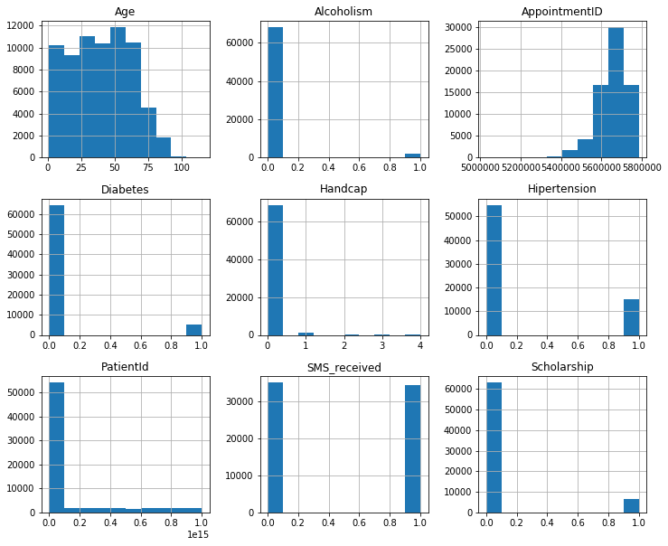

```python
#Histagram for all column in the dataset
df_all.hist(figsize=(12,10));
```

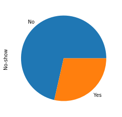

```python
#Apply pie diagram for NO show column to show the presentage of no show up patients
df_all['No-show'].value_counts().plot(kind='pie');
```

```python
#Apply count of attend or not attend the Appointment
df_all['No-show'].value_counts()
```

```
No     49894
Yes    19934
Name: No-show, dtype: int64
```

> Number of attended appointment is 49894 which the precentage represent 71%, and the number of did't attend appointment is 19934 which is represent 29%.

> To visulize the data need to filter the data to the patients show up and no show up.

```python
# Filter the data to the no show up and show up by mask
mask1=df_all['No-show']=='No'
mask2=df_all['No-show']=='Yes'
#Generate variables for the mask
sh=df_all[mask1]
ns=df_all[mask2]
```

> Visulize the patients age

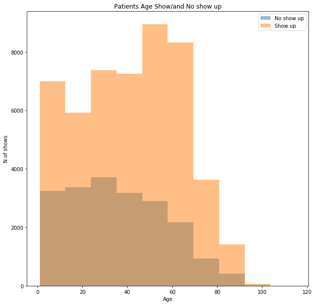

```python
#Insert plot
fig, ax=plt.subplots(figsize=(10,10))
#Generate the first plot
ax.hist(ns['Age'], alpha=0.5, label='No show up')
#Generate second plot
ax.hist (sh['Age'], alpha=0.5, label='Show up')
#Set the title
ax.set_title('Patients Age Show/and No show up')
#Set value for x label
ax.set_xlabel('Age')
#Set value for y label
ax.set_ylabel('N.of shows')
#Set the location for the legend
ax.legend(loc='upper right')
#show the plot
plt.show()
```

> As show the ages from 25 to 35 is mostly didn't show up

### Research Question 2 (In which gender the patients no show up?)

```python
#Count the number of Female and Male not show up
ns['Gender'].value_counts()
```

```
F    13380
M     6554
Name: Gender, dtype: int64
```

> Visulize the gender no show up

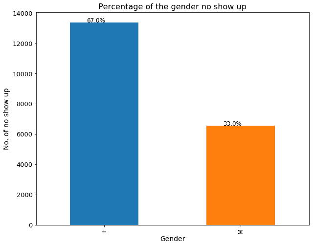

```python
#Insert plot
ax = ns['Gender'].value_counts().plot(kind='bar', figsize=(10,8), fontsize=13);
#set title
ax.set_title("Percentage of the gender no show up", fontsize=16)
#set y label
ax.set_ylabel("No. of no show up", fontsize=14);
#set y value
ax.set_yticks([0, 2000, 4000, 6000, 8000, 10000, 12000, 14000])
#set x label
ax.set_xlabel('Gender', fontsize=14)
# create a list to collect the plot data
totals = []
# find the values and append to list
for i in ax.patches:
    totals.append(i.get_height())
# set individual bar lables using above list
total = sum(totals)
for i in ax.patches:
    # get_x pulls left or right; get_height pushes up or down
    ax.text(i.get_x()+.12, i.get_height()-3, \
            str(round((i.get_height()/total)*100))+'%', fontsize=12,
                color='black')
```

> Which the number of Female didn't attend is 13380 and represent 67%, and the number of Male is 6554 which represent 33%.

## Conclusions

> No show up data set contain 110527 row and 14 column. The data set didn't have missing or duplicate value but contain invalied value like in age number(contain -1, and 0 value) and in appointment day the appointment day come before schaduled day. For that the data fram size which used in analysis contain 69828 rows and 14 column.

> In the beginning of the research we asked in which age the patient no show up? and in which gender the patients no show up? Number of attended appointment is 49894 which the precentage represent 71%, and the number of did't attend appointment is 19934 which is represent 29%. The age mostly no show up from 25 to 35, on other hand the age from 50 to 60 mostly show up. Thw gender mostly no show up was in female by 13380 which represent 67%, on other hand the number of Male is 6554 which represent 33%.

> In conclusion, the patients no show up represent 29% of the clean dataset. The age from 25 to 35 mostly no show up, and the most of no show up was in female. The limitation i faced in this project was in the way of clean the data set from invalied value. Also the way in represent the presentage in bar chart. I faced performance issue when i run the code the kernal is busy(*), which make me difficult to manage the tmie, which is lead me took a lot of dates to perform this project.

> The references was in udacity lecture, and stack Overflow website.